# Майнор "Интеллектуальный анализ данных"

# Курс "Современные методы машинного обучения"

# Лабораторная работа №1. Image Classification.

В данной лабораторной работе вам предлагается обучить модель на основе нейронной сети для распознавания рукописных букв английского алфавита.

## Данные

Данные представлены двумя датасетами: обучающим (`train`) и тестовым (`test`). Изображения для каждого датасета находятся в `images.zip`.

Обучающая выборка состоит из 65000 изображений - по 2500 изображений для каждой буквы.  
Тестовая выборка состоит из 13000 изображений - по 500 изображений для каждой буквы.

Все изображения - монохромные (но в формате RGB), размерности $28 \times 28$ пикселей, в формате JPEG. В названии каждого файла содержатся буква, которая представлена на изображении, и уникальный номер изображения: `a_00002.jpg`.

**NB:** Все изображения представлены в перевернутом виде, для корректного отображения их нужно сначала транспонировать.

```python
import numpy as np
import matplotlib.pyplot as plt
import torch
```

```python
pic = plt.imread('images/train/a/a_00002.jpg')
print(pic.shape)
```

```
(28, 28, 3)
```

```python
pic = np.transpose(pic, axes=(1, 0, 2))
```

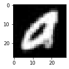

```python
plt.figure(figsize=(2,2))
plt.imshow(pic)
plt.show()
```

```python
torch.tensor(pic)
```

```
tensor([[[0, 0, 0],
         [0, 0, 0],
         [0, 0, 0],
         ...,
         [1, 1, 1],
         [1, 1, 1],
         [0, 0, 0]],

        [[0, 0, 0],
         [0, 0, 0],
         [0, 0, 0],
         ...,
         [1, 1, 1],
         [1, 1, 1],
         [0, 0, 0]],

        [[0, 0, 0],
         [0, 0, 0],
         [0, 0, 0],
         ...,
         [1, 1, 1],
         [1, 1, 1],
         [0, 0, 0]],

        ...,

        [[3, 3, 3],
         [0, 0, 0],
         [2, 2, 2],
         ...,
         [0, 0, 0],
         [0, 0, 0],
         [0, 0, 0]],

        [[3, 3, 3],
         [0, 0, 0],
         [0, 0, 0],
         ...,
         [0, 0, 0],
         [0, 0, 0],
         [0, 0, 0]],

        [[4, 4, 4],
         [0, 0, 0],
         [0, 0, 0],
         ...,
         [0, 0, 0],
         [0, 0, 0],
         [0, 0, 0]]], dtype=torch.uint8)
```

Ваша задача - создать и обучить модель на основе нейронной сети, которая будет предсказывать букву на картинке.  
Обучение необходимо проводить на данных из `train`, качество модели проверять на данных из `test`.  
Целевая метрика - accuracy.  
Для моделирования необходимо использовать `pytorch`.

## Основные задания

### Задание 1

*Вес в общей оценке - 0.35*

1. Постройте и обучите модели с 2-мя и 3-мя полносвязными (dense) скрытыми слоями.  
   При моделировании необходимо попробовать разные параметры нейронной сети - число нейронов на каждом слое, learning rate, batch size, функции активации, регуляризации и т.д. Оцените качество моделей с различными параметрами, проведите сравнительный анализ.
2. Для наилучшей модели постройте confusion matrix результатов предсказаний модели на тестовых данных.  
   Насколько равномерно обучилась ваша модель? Приведите буквы с самой лучшей и с самой худшей точностью детекции.
3. Найдите 10 пар букв, которые чаще всего путаются между собой, дайте возможное объяснение. Приведите примеры с картинками, которые были детектированы с ошибкой.
4. Возьмите первую букву вашей фамилии и укажите её точность детекции. С какими буквами ваша модель чаще всего путает эту букву?

### Задание 2

*Вес в общей оценке - 0.35*

1. Постройте и обучите модели нейронной сети с 1-м, 2-мя и 3-мя сверточными слоями.  
   Попробуйте различные значения параметров сверток и числа фильтров на каждом слое. Оцените качество моделей с различными параметрами, проведите сравнительный анализ.
2. Для наилучшей конфигурации из предыдущего пункта, сравните, как меняется качество модели при увеличении размера батча при использовании BatchNorm и GroupNorm.

### Задание 3

Обучите модель с точностью (accuracy) на тестовых данных:

- `>= 0.85` +1 балл
- `>= 0.95` +2 балла
- `>= 0.99` +3 балла

## Задание 1

### Пункт 1

```python
import os
from sklearn.model_selection import train_test_split
from torch import nn
from torch.utils.data import DataLoader
```

```python
def get_data_and_targets_lst(path):
    data=[]
    targets=[]
    for root, currentDirectory, files in os.walk(path):
        for file in files:
            pic = plt.imread(os.path.join(root, file))
            pic = torch.tensor(np.transpose(pic, axes=(1, 0, 2)))
            pic = torch.div(pic, 255)
            target = ord(file[0]) - ord('a')
            data.append(pic)
            targets.append(target)
    return data,targets
```

```python
class MyDataset(torch.utils.data.Dataset):

    def __init__(self, x, y):
        self.x=x
        self.y=y

    def __len__(self):
        return len(self.x)

    def __getitem__(self, idx):
        return self.x[idx],self.y[idx]
```

```python
X,y = get_data_and_targets_lst("images/train")
```

```python
X[60000].dtype
```

```
torch.float32
```

```
24
```

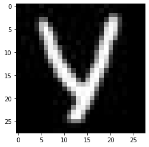

```python
plt.imshow(X[60000])
print(y[60000])
```

```python
len(y)
```

```
65000
```

```python
X_train, X_test, y_train, y_test = train_test_split(X,y, test_size=0.2)
```

```python
len(X_test), len(y_test)
```

```
(13000, 13000)
```

```python
train_dataset = MyDataset(X_train, y_train)
test_dataset = MyDataset(X_test, y_test)
```

```python
batch_size=64
train_dataloader = DataLoader(train_dataset, batch_size=batch_size)
test_dataloader = DataLoader(test_dataset, batch_size=batch_size)
for batch, (X, y) in enumerate(train_dataloader):
    print(batch)
    print(y)
    print("Shape of X [N, C, H, W]: ", X.shape)
    print("Shape of y: ", y.shape, y.dtype)
    break
```

```
0
tensor([23, 15,  7, 18,  8,  5, 13, 23, 15,  7,  2, 14,  7, 18, 14,  5,  6, 18,
        21,  2,  4,  4,  3,  4, 24, 11,  5,  2, 13,  0, 12, 17, 18, 13, 20,  8,
        21,  5, 22,  0,  5, 22,  2, 21, 16,  6,  0, 24, 22, 10, 18, 13,  5,  1,
        10,  9, 14, 18, 22, 22, 21, 12, 13, 19])
Shape of X [N, C, H, W]:  torch.Size([64, 28, 28, 3])
Shape of y:  torch.Size([64]) torch.int64
```

```python
device = "cuda" if torch.cuda.is_available() else "cpu"
print("Using {} device".format(device))
```

```
Using cpu device
```

```python
def train(dataloader, model, loss_fn, optimizer, to_NCHW = False):
    size = len(dataloader.dataset)
    model.train()
    for batch, (X, y) in enumerate(dataloader):
        if to_NCHW:
            X = X.permute(0, 3, 1, 2)
        X, y = X.to(device), y.to(device)

        pred = model(X)
        loss = loss_fn(pred, y)

        optimizer.zero_grad()
        loss.backward()
        optimizer.step()

        if batch % 100 == 0:
            loss, current = loss.item(), batch * len(X)
            print(f"loss: {loss:>7f}  [{current:>5d}/{size:>5d}]")
```

```python
def test(dataloader, model, loss_fn, to_NCHW = False):
    size = len(dataloader.dataset)
    num_batches = len(dataloader)
    model.eval()
    test_loss, correct = 0, 0
    with torch.no_grad():
        for X, y in dataloader:
            if to_NCHW:
                X = X.permute(0, 3, 1, 2)
            X, y = X.to(device), y.to(device)
            pred = model(X)
            test_loss += loss_fn(pred, y).item()
            correct += (pred.argmax(1) == y).type(torch.float).sum().item()
    test_loss /= num_batches
    correct /= size
    print(f"Test Error: \n Accuracy: {(100*correct):>0.1f}%, Avg loss: {test_loss:>8f} \n")
```

```python
def get_model_accuracy(dataloader, model, to_NCHW = False):
    size = len(dataloader.dataset)
    correct = 0
    with torch.no_grad():
        for X, y in dataloader:
            if to_NCHW:
                X = X.permute(0, 3, 1, 2)
            X, y = X.to(device), y.to(device)
            pred = model(X)
            correct += (pred.argmax(1) == y).type(torch.float).sum().item()
    return correct / size
```

```python
def get_all_model_predictions(dataloader, model):
    size = len(dataloader.dataset)
    correct = 0
    predictions = []
    with torch.no_grad():
        for X, y in dataloader:
            X, y = X.to(device), y.to(device)
            pred = model(X)
            predictions.extend(pred.argmax(1))
    return list(map(lambda x : x.item(), predictions))
```

```python
def learning_cycle(epochs, model, loss_fn, optimizer, to_NCHW = False):
    for t in range(epochs):
        print(f"Epoch {t+1}\n-------------------------------")
        train(train_dataloader, model, loss_fn, optimizer, to_NCHW = to_NCHW)
        test(test_dataloader, model, loss_fn, to_NCHW = to_NCHW)
```

```python
class NeuralNetwork(nn.Module):
    def __init__(self):
        super(NeuralNetwork, self).__init__()
        self.flatten = nn.Flatten()
        self.linear_relu_stack = nn.Sequential(
            nn.Linear(28*28*3, 512),
            nn.ReLU(),
            nn.Linear(512, 512),
            nn.ReLU(),
            nn.Linear(512, 26),
        )

    def forward(self, x):
        x = self.flatten(x)
        logits = self.linear_relu_stack(x)
        return logits
```

```python
model_lin3 = NeuralNetwork()
```

```python
loss_fn = nn.CrossEntropyLoss()
optimizer = torch.optim.SGD(model_lin3.parameters(), lr=0.001)
learning_cycle(100, model_lin3, loss_fn, optimizer)
```

```
Epoch 1
-------------------------------
loss: 3.257941  [    0/52000]
loss: 3.253754  [ 6400/52000]
loss: 3.247673  [12800/52000]
loss: 3.240828  [19200/52000]
loss: 3.246015  [25600/52000]
loss: 3.241989  [32000/52000]
loss: 3.234846  [38400/52000]
loss: 3.236881  [44800/52000]
loss: 3.218539  [51200/52000]
Test Error:
 Accuracy: 12.4%, Avg loss: 3.227562

Epoch 2
-------------------------------
loss: 3.220181  [    0/52000]
loss: 3.214712  [ 6400/52000]
loss: 3.211275  [12800/52000]
loss: 3.200249  [19200/52000]
loss: 3.204555  [25600/52000]
loss: 3.205428  [32000/52000]
loss: 3.192484  [38400/52000]
loss: 3.194419  [44800/52000]
loss: 3.172067  [51200/52000]
Test Error:
 Accuracy: 27.0%, Avg loss: 3.182704

Epoch 3
-------------------------------
loss: 3.170477  [    0/52000]
loss: 3.161946  [ 6400/52000]
loss: 3.161450  [12800/52000]
loss: 3.143021  [19200/52000]
loss: 3.146265  [25600/52000]
loss: 3.151277  [32000/52000]
loss: 3.129750  [38400/52000]
loss: 3.130108  [44800/52000]
loss: 3.105080  [51200/52000]
Test Error:
```

[output cut: 1344 more lines]

```
 Accuracy: 81.1%, Avg loss: 0.656102

Epoch 100
-------------------------------
loss: 0.706833  [    0/52000]
loss: 0.631347  [ 6400/52000]
loss: 0.691072  [12800/52000]
loss: 0.573095  [19200/52000]
loss: 0.641847  [25600/52000]
loss: 0.952551  [32000/52000]
loss: 0.612590  [38400/52000]
loss: 0.701181  [44800/52000]
loss: 0.448787  [51200/52000]
Test Error:
 Accuracy: 81.3%, Avg loss: 0.652005
```

```python
X_train[0].shape
```

```
torch.Size([28, 28, 3])
```

```python
pred = model_lin3(X_train[30000].reshape([1,28,28,3]))
```

```python
pred,y_train[30000]
```

```
(tensor([[  7.1546,  -1.2263,   6.3160,  -0.2023,   6.7015,  -1.9704,   1.6220,
           -0.1928,  -4.7703,  -5.2024,   4.5642,  -2.4500,   0.1675,   3.7997,
            3.1503, -12.2828,   1.0887,   2.3411,  -2.1427,   0.1692,   4.0907,
           -1.9251,   0.7803,  -0.2047,  -7.2773,   3.3846]],
        grad_fn=<AddmmBackward0>),
 2)
```

```python
class NeuralNetwork2(nn.Module):
    def __init__(self):
        super(NeuralNetwork2, self).__init__()
        self.flatten = nn.Flatten()
        self.linear_sigmoid_stack = nn.Sequential(
            nn.Linear(28*28*3, 512),
            nn.Sigmoid(),
            nn.Linear(512, 26),
        )

    def forward(self, x):
        x = self.flatten(x)
        logits = self.linear_sigmoid_stack(x)
        return logits
```

```python
model_lin2 = NeuralNetwork2()
```

```python
loss_fn = nn.CrossEntropyLoss()
optimizer2 = torch.optim.SGD(model_lin2.parameters(), lr=0.01)
learning_cycle(100, model_lin2, loss_fn, optimizer2)
```

```
Epoch 1
-------------------------------
loss: 3.349135  [    0/52000]
loss: 3.229443  [ 6400/52000]
loss: 3.182739  [12800/52000]
loss: 3.154847  [19200/52000]
loss: 3.118899  [25600/52000]
loss: 3.107059  [32000/52000]
loss: 3.015782  [38400/52000]
loss: 2.953204  [44800/52000]
loss: 2.934583  [51200/52000]
Test Error:
 Accuracy: 35.0%, Avg loss: 2.912579

Epoch 2
-------------------------------
loss: 2.914171  [    0/52000]
loss: 2.840272  [ 6400/52000]
loss: 2.801942  [12800/52000]
loss: 2.707411  [19200/52000]
loss: 2.639117  [25600/52000]
loss: 2.694268  [32000/52000]
loss: 2.485656  [38400/52000]
loss: 2.381102  [44800/52000]
loss: 2.427376  [51200/52000]
Test Error:
 Accuracy: 48.5%, Avg loss: 2.373479

Epoch 3
-------------------------------
loss: 2.347242  [    0/52000]
loss: 2.274589  [ 6400/52000]
loss: 2.319045  [12800/52000]
loss: 2.141729  [19200/52000]
loss: 2.128472  [25600/52000]
loss: 2.267372  [32000/52000]
loss: 2.003851  [38400/52000]
loss: 1.927014  [44800/52000]
loss: 2.010900  [51200/52000]
Test Error:
```

[output cut: 1344 more lines]

```
 Accuracy: 83.5%, Avg loss: 0.563311

Epoch 100
-------------------------------
loss: 0.487370  [    0/52000]
loss: 0.581625  [ 6400/52000]
loss: 0.582971  [12800/52000]
loss: 0.461358  [19200/52000]
loss: 0.503760  [25600/52000]
loss: 0.859459  [32000/52000]
loss: 0.505743  [38400/52000]
loss: 0.648669  [44800/52000]
loss: 0.395158  [51200/52000]
Test Error:
 Accuracy: 83.6%, Avg loss: 0.560341
```

Более простая модель с двумя линейными слоями учится значительно быстрее и выдает результаты приемлемые результаты

```python
Xt,yt = get_data_and_targets_lst("images/test")
```

```python
final_test_dataset = MyDataset(Xt, yt)
final_test_dataloader = DataLoader(final_test_dataset, batch_size=batch_size)
```

```python
get_model_accuracy(final_test_dataloader, model_lin3)
```

```
0.812
```

```python
get_model_accuracy(final_test_dataloader, model_lin2)
```

```
0.838
```

### Пункт 2

```python
from sklearn.metrics import confusion_matrix
import seaborn as sns
import pandas as pd
```

```python
predictions = get_all_model_predictions(final_test_dataloader, model_lin2)
len(predictions)
```

```
13000
```

```python
cf_matrix = confusion_matrix(yt, predictions)
```

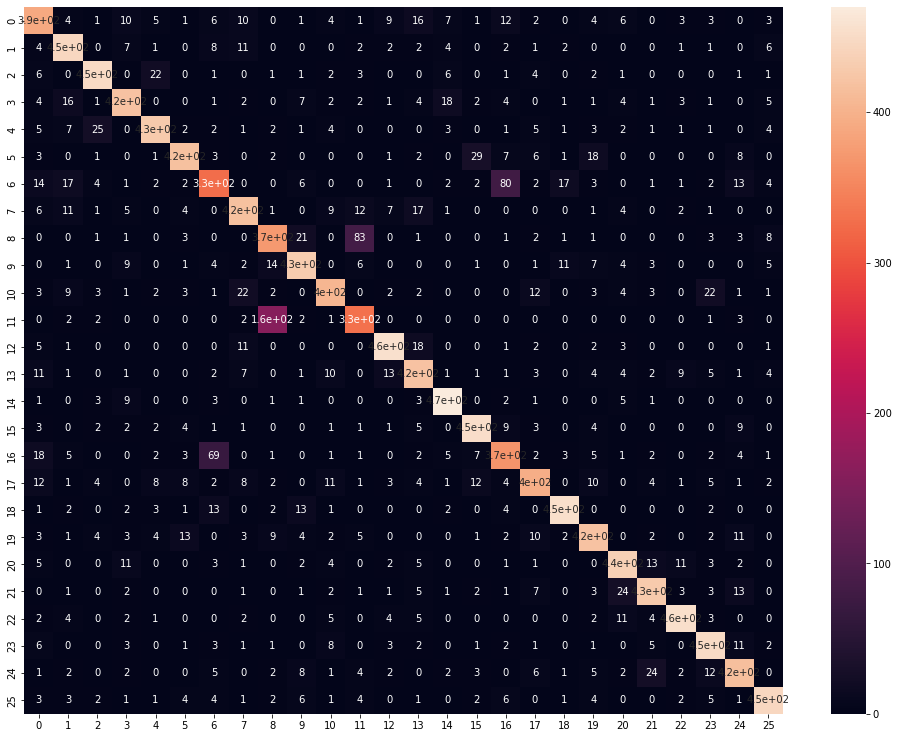

```python
plt.figure(figsize=(17,13))
sns.heatmap(cf_matrix, annot=True)
```

```
<BarContainer object of 26 artists>
```

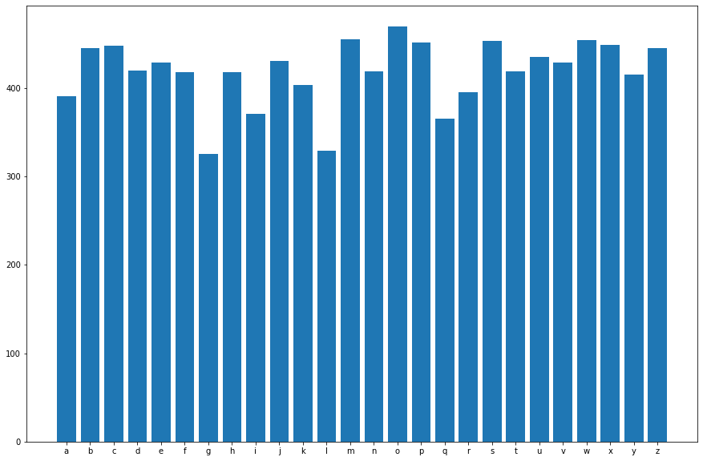

```python
plt.figure(figsize=(15,10))
letters_stat = [cf_matrix[i][i] for i in range(26)]
plt.bar([chr(i+97) for i in range(26)], letters_stat)
```

```python
chr(np.array(letters_stat).argmax() + 97), max(letters_stat)/500
```

```
('o', 0.94)
```

```python
chr(np.array(letters_stat).argmin() + 97), min(letters_stat)/500
```

```
('g', 0.652)
```

По выведенным данным видно, что лучше всего угадывается буква "о", а хуже всего - буква "g"

Предположительно такой результат вышел из за простоты структуры буквы "о" и из-за схожести букв "g", "p" и "q"

### Пункт 3

```python
def get_confusing_letters(cf_matrix, amount=10):
    matrix = cf_matrix.copy()
    for i in range(26):
        matrix[i][i] = 0
    confusion = []
    for i in range(26):
        for j in range(26):
            if len(confusion)<amount:
                confusion.append((matrix[i][j],chr(i+97),chr(j+97)))
            elif min(confusion, key=lambda el: el[0])[0] < matrix[i][j]:
                confusion = sorted(confusion, key=lambda el: el[0])
                confusion[0] = (matrix[i][j],chr(i+97),chr(j+97))
    return sorted(confusion, key=lambda el: el[0])
```

```python
get_confusing_letters(cf_matrix, 20)
```

```
[(16, 'a', 'n'),
 (17, 'h', 'n'),
 (17, 'g', 's'),
 (17, 'g', 'b'),
 (18, 'q', 'a'),
 (18, 'm', 'n'),
 (18, 'f', 't'),
 (18, 'd', 'o'),
 (21, 'i', 'j'),
 (22, 'k', 'x'),
 (22, 'k', 'h'),
 (22, 'c', 'e'),
 (24, 'y', 'v'),
 (24, 'v', 'u'),
 (25, 'e', 'c'),
 (29, 'f', 'p'),
 (69, 'q', 'g'),
 (80, 'g', 'q'),
 (83, 'i', 'l'),
 (158, 'l', 'i')]
```

```python
wrong_inds = []
for i in range(len(predictions)):
    if predictions[i] != yt[i]:
        wrong_inds.append(i)
```

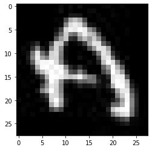

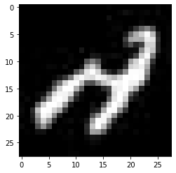

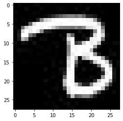

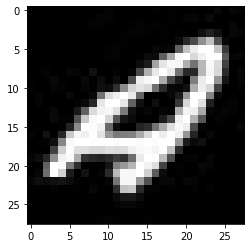

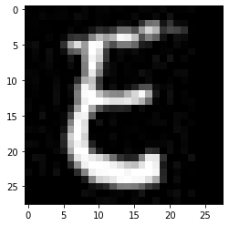

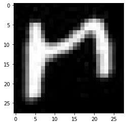

```python
for i in [5,100,123,34,300,1200]:
    plt.imshow(Xt[wrong_inds[i]])
    plt.show()
```

### Пункт 4

```python
sind = ord("m") - 97
cf_matrix[sind][sind]/500
```

```
0.912
```

```python
sind
```

```
12
```

Если взглянуть на confusion matrix можно увидеть, что чаще всего букву "m" модель путает с буквой под номером 13 ("n")

```python
chr(97+13), chr(97)
```

```
('n', 'a')
```

## Задание 2

```python
conv1 = nn.Conv2d(3, 6, 5)
pool = nn.MaxPool2d(2, 2)
conv2 = nn.Conv2d(6, 18, 5)
```

```python
for batch, (X, y) in enumerate(train_dataloader):
    X = X.permute(0, 3, 1, 2)
    print(X.shape)
    X = conv1(X)
    print(X.shape)
    X = pool(X)
    print(X.shape)
    X = conv2(X)
    print(X.shape)
    X = pool(X)
    print(X.shape)
    break
```

```
torch.Size([64, 3, 28, 28])
torch.Size([64, 6, 24, 24])
torch.Size([64, 6, 12, 12])
torch.Size([64, 18, 8, 8])
torch.Size([64, 18, 4, 4])
```

```python
class Conv2NeuralNetwork(nn.Module):
    def __init__(self):
        super(Conv2NeuralNetwork, self).__init__()
        self.convolution_relu_stack = nn.Sequential(
            nn.Conv2d(3, 6, 5),
            nn.ReLU(),
            nn.MaxPool2d(2, 2),

            nn.Conv2d(6, 18, 5),
            nn.ReLU(),
            nn.MaxPool2d(2, 2),
        )

        self.flatten = nn.Flatten()
        self.linear_relu_stack = nn.Sequential(
            nn.Linear(18*4*4,120),
            nn.ReLU(),
            nn.Linear(120,26)
        )
    def forward(self, x):
        x = self.convolution_relu_stack(x)
        x = self.flatten(x)
        logits = self.linear_relu_stack(x)
        return logits
```

```python
for batch, (X, y) in enumerate(train_dataloader):
    c = Conv2NeuralNetwork()
    print(c(X.permute(0, 3, 1, 2)).shape)
    break
```

```
torch.Size([64, 26])
```

```python
model_conv2 = Conv2NeuralNetwork()
```

```python
loss_fn = nn.CrossEntropyLoss()
optimizer = torch.optim.SGD(model_conv2.parameters(), lr=0.001)
learning_cycle(100, model_conv2, loss_fn, optimizer, to_NCHW=True)
```

```
Epoch 1
-------------------------------
loss: 3.271477  [    0/52000]
loss: 3.275589  [ 6400/52000]
loss: 3.255172  [12800/52000]
loss: 3.259875  [19200/52000]
loss: 3.254752  [25600/52000]
loss: 3.252551  [32000/52000]
loss: 3.265841  [38400/52000]
loss: 3.256036  [44800/52000]
loss: 3.265855  [51200/52000]
Test Error:
 Accuracy: 5.5%, Avg loss: 3.257992

Epoch 2
-------------------------------
loss: 3.267635  [    0/52000]
loss: 3.272420  [ 6400/52000]
loss: 3.253002  [12800/52000]
loss: 3.257333  [19200/52000]
loss: 3.250028  [25600/52000]
loss: 3.249674  [32000/52000]
loss: 3.261310  [38400/52000]
loss: 3.251848  [44800/52000]
loss: 3.262164  [51200/52000]
Test Error:
 Accuracy: 5.7%, Avg loss: 3.254000

Epoch 3
-------------------------------
loss: 3.262738  [    0/52000]
loss: 3.268464  [ 6400/52000]
loss: 3.248681  [12800/52000]
loss: 3.253494  [19200/52000]
loss: 3.242398  [25600/52000]
loss: 3.244540  [32000/52000]
loss: 3.253617  [38400/52000]
loss: 3.244439  [44800/52000]
loss: 3.255925  [51200/52000]
Test Error:
```

[output cut: 1344 more lines]

```
 Accuracy: 88.6%, Avg loss: 0.365189

Epoch 100
-------------------------------
loss: 0.178104  [    0/52000]
loss: 0.488904  [ 6400/52000]
loss: 0.371634  [12800/52000]
loss: 0.219439  [19200/52000]
loss: 0.235364  [25600/52000]
loss: 0.500077  [32000/52000]
loss: 0.238119  [38400/52000]
loss: 0.346423  [44800/52000]
loss: 0.212876  [51200/52000]
Test Error:
 Accuracy: 88.6%, Avg loss: 0.364376
```

```python
conv1 = nn.Conv2d(3, 8, 3)
pool = nn.MaxPool2d(2, 2)
conv2 = nn.Conv2d(8, 16, 4)
conv3 = nn.Conv2d(16, 18, 2)
```

```python
for batch, (X, y) in enumerate(train_dataloader):
    X = X.permute(0, 3, 1, 2)
    print(X.shape)
    X = conv1(X)
    print(X.shape)
    X = pool(X)
    print(X.shape)
    X = conv2(X)
    print(X.shape)
    X = pool(X)
    print(X.shape)
    X = conv3(X)
    print(X.shape)
    X = pool(X)
    print(X.shape)
    break
```

```
torch.Size([64, 3, 28, 28])
torch.Size([64, 8, 26, 26])
torch.Size([64, 8, 13, 13])
torch.Size([64, 16, 10, 10])
torch.Size([64, 16, 5, 5])
torch.Size([64, 18, 4, 4])
torch.Size([64, 18, 2, 2])
```

```python
class Conv3NeuralNetwork(nn.Module):
    def __init__(self):
        super(Conv3NeuralNetwork, self).__init__()
        self.convolution_relu_stack = nn.Sequential(
            nn.Conv2d(3, 8, 3),
            nn.MaxPool2d(2, 2),
            nn.Conv2d(8, 16, 4),
            nn.MaxPool2d(2, 2),
            nn.Conv2d(16, 18, 2),
            nn.MaxPool2d(2, 2),
        )

        self.flatten = nn.Flatten()
        self.linear_relu_stack = nn.Sequential(
            nn.Linear(18*2*2,64),
            nn.ReLU(),
            nn.Linear(64,48),
            nn.ReLU(),
            nn.Linear(48,26),
        )
    def forward(self, x):
        x = self.convolution_relu_stack(x)
        x = self.flatten(x)
        logits = self.linear_relu_stack(x)
        return logits
```

```python
model_conv3 = Conv3NeuralNetwork()
```

```python
loss_fn = nn.CrossEntropyLoss()
optimizer = torch.optim.SGD(model_conv3.parameters(), lr=0.01)
learning_cycle(100, model_conv3, loss_fn, optimizer, to_NCHW=True)
```

```
Epoch 1
-------------------------------
loss: 3.269760  [    0/52000]
loss: 3.254687  [ 6400/52000]
loss: 3.258521  [12800/52000]
loss: 3.271180  [19200/52000]
loss: 3.261063  [25600/52000]
loss: 3.258750  [32000/52000]
loss: 3.265060  [38400/52000]
loss: 3.253367  [44800/52000]
loss: 3.259740  [51200/52000]
Test Error:
 Accuracy: 3.6%, Avg loss: 3.255656

Epoch 2
-------------------------------
loss: 3.261729  [    0/52000]
loss: 3.251884  [ 6400/52000]
loss: 3.254426  [12800/52000]
loss: 3.257806  [19200/52000]
loss: 3.255751  [25600/52000]
loss: 3.250705  [32000/52000]
loss: 3.255015  [38400/52000]
loss: 3.248677  [44800/52000]
loss: 3.250279  [51200/52000]
Test Error:
 Accuracy: 7.0%, Avg loss: 3.244168

Epoch 3
-------------------------------
loss: 3.248154  [    0/52000]
loss: 3.239626  [ 6400/52000]
loss: 3.240220  [12800/52000]
loss: 3.219790  [19200/52000]
loss: 3.229983  [25600/52000]
loss: 3.199586  [32000/52000]
loss: 3.158108  [38400/52000]
loss: 3.095598  [44800/52000]
loss: 2.718027  [51200/52000]
Test Error:
```

[output cut: 1344 more lines]

```
 Accuracy: 89.8%, Avg loss: 0.392280

Epoch 100
-------------------------------
loss: 0.108751  [    0/52000]
loss: 0.151979  [ 6400/52000]
loss: 0.139724  [12800/52000]
loss: 0.128079  [19200/52000]
loss: 0.120070  [25600/52000]
loss: 0.221518  [32000/52000]
loss: 0.091484  [38400/52000]
loss: 0.094169  [44800/52000]
loss: 0.155769  [51200/52000]
Test Error:
 Accuracy: 89.8%, Avg loss: 0.393122
```

```python
get_model_accuracy(final_test_dataloader, model_conv3, to_NCHW=True)
```

```
0.9011538461538462
```

```python
class Conv1NeuralNetwork(nn.Module):
    def __init__(self):
        super(Conv2NeuralNetwork, self).__init__()
        self.convolution_relu_stack = nn.Sequential(
            nn.Conv2d(3, 6, 5),
            nn.ReLU(),
            nn.MaxPool2d(2, 2),

            nn.Conv2d(6, 18, 5),
            nn.ReLU(),
            nn.MaxPool2d(2, 2),
        )

        self.flatten = nn.Flatten()
        self.linear_relu_stack = nn.Sequential(
            nn.Linear(18*4*4,120),
            nn.ReLU(),
            nn.Linear(120,26)
        )
    def forward(self, x):
        x = self.convolution_relu_stack(x)
        x = self.flatten(x)
        logits = self.linear_relu_stack(x)
        return logits
```

```python
for batch, (X, y) in enumerate(train_dataloader):
    X = X.permute(0, 3, 1, 2)
    print(X.shape)
    X = conv1(X)
    print(X.shape)
    X = pool(X)
    break
```

```
torch.Size([64, 3, 28, 28])
torch.Size([64, 8, 26, 26])
```

```python
class Conv3NeuralNetworkBN(nn.Module):
    def __init__(self):
        super(Conv3NeuralNetwork, self).__init__()
        self.convolution_relu_stack = nn.Sequential(
            nn.Conv2d(3, 8, 3),
            nn.MaxPool2d(2, 2),
            nn.BatchNorm2d(8),
            nn.Conv2d(8, 16, 4),
            nn.MaxPool2d(2, 2),
            nn.Conv2d(16, 18, 2),
            nn.MaxPool2d(2, 2),
        )

        self.flatten = nn.Flatten()
        self.linear_relu_stack = nn.Sequential(
            nn.Linear(18*2*2,64),
            nn.ReLU(),
            nn.Linear(64,48),
            nn.ReLU(),
            nn.Linear(48,26),
        )
    def forward(self, x):
        x = self.convolution_relu_stack(x)
        x = self.flatten(x)
        logits = self.linear_relu_stack(x)
        return logits
```

```python
class Conv3NeuralNetworkGN(nn.Module):
    def __init__(self):
        super(Conv3NeuralNetwork, self).__init__()
        self.convolution_relu_stack = nn.Sequential(
            nn.Conv2d(3, 8, 3),
            nn.MaxPool2d(2, 2),
            nn.GroupNorm(4,8),
            nn.Conv2d(8, 16, 4),
            nn.MaxPool2d(2, 2),
            nn.Conv2d(16, 18, 2),
            nn.MaxPool2d(2, 2),
        )

        self.flatten = nn.Flatten()
        self.linear_relu_stack = nn.Sequential(
            nn.Linear(18*2*2,64),
            nn.ReLU(),
            nn.Linear(64,48),
            nn.ReLU(),
            nn.Linear(48,26),
        )
    def forward(self, x):
        x = self.convolution_relu_stack(x)
        x = self.flatten(x)
        logits = self.linear_relu_stack(x)
        return logits
```

## Задание 3

```python
model90 = NeuralNetwork2()
model90.load_state_dict(torch.load("models/model90.pth"))
```

```
<All keys matched successfully>
```

```python
get_model_accuracy(final_test_dataloader, model90)
```

```
0.9027692307692308
```

## Бонусные задания

**Задание 1 (1 балл).**

Напишите на листке белой бумаги (маркером или ручкой) от 5 разных букв (можно больше 5 букв в целом с повторениями, но должно быть минимум 5 разных) английского алфавита (в датасете есть как прописные, так и строчные буквы). Сфотографируйте букву и приведите её картинку к размеру $28\times28$ и, желательно, к чёрно-белой палитре цветов. Передайте получившиеся изображения вашей модели и выполните предсказание, оцените результат.

**Tips:**

- В датасете все буквы занимают практически всё пространство картинки по высоте или ширине (или вместе). Если ваша буква будет слишком маленькой или большой, это может повлиять на результат детекции.
- Помните, что буква должна быть белого цвета, а фон - чёрного.
- Описание ваших действий при выполнении этого задания (что вы использовали, чтобы привести картинку к нужному виду) категорически приветствуется :)

**Задание 2 (1 балл):**

Используйте transfer learning подход для решения задачи - дообучите какую-либо модель, предобученную на ImageNet, для классификации рукописных букв. Оцените качество решения.  
В качестве предобученой модели можно взять одну из [torchvision models](https://pytorch.org/vision/stable/models.html).

**Задание 3 (1 балл):**

Добавьте вывод значений функции потерь и accuracy в tensorboard.  
Метрики нужно выводить и для обучающей, и для тестовой выборки.

## Бонусное задание 1

```python
model90n = NeuralNetwork2()
model90n.load_state_dict(torch.load("models/model90.pth"))
```

```
<All keys matched successfully>
```

```python
model90 = Conv3NeuralNetwork()
model90.load_state_dict(torch.load("models/model91conv3.pth"))
```

```
<All keys matched successfully>
```

```python
mX,my = get_data_and_targets_lst("my_images")
```

```python
for el in mX:
    print(el.shape)
```

```
torch.Size([62, 62, 3])
torch.Size([118, 118, 3])
torch.Size([70, 70, 3])
torch.Size([68, 68, 3])
torch.Size([82, 82, 3])
```

```python
import cv2
```

[figure not shown]

```python
image = plt.imread('my_images/m.jpg')
plt.imshow(image)

plt.show()
```

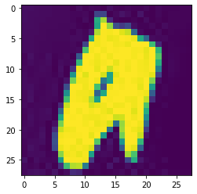

```python
image = cv2.imread('my_images/a.jpg')
image = cv2.resize(image, (28,28), interpolation=cv2.INTER_AREA)
image = cv2.cvtColor(image, cv2.COLOR_RGB2GRAY)
image= np.invert(image)
plt.imshow(image)
plt.show()
```

```python
result = np.zeros([28, 28, 3])
```

```python
for i in range(28):
    for j in range(28):
        result[i][j][0] = image[i][j]/255
        result[i][j][1] = image[i][j]/255
        result[i][j][2] = image[i][j]/255
```

```python
result = torch.from_numpy(result)
result = result.float()
result.dtype
```

```
torch.float32
```

```python
model90(result.reshape([1,3,28,28]))
```

```
tensor([[  2.4015,   5.9362,  -7.1029,   2.2771,  -6.8648, -10.8717,   4.6448,
           0.9583,  -0.3275,   2.2892,  -3.1079,  -2.3010,   6.5460,   2.0091,
           2.1614,  -1.6511,   8.4356,  -4.6564,  -3.7444, -10.5170,   0.0392,
           1.4838,   6.2443,  -4.7568,   2.3331,  -1.1128]],
       grad_fn=<AddmmBackward0>)
```

## Бонусное задание 2

```python
import torchvision.models as models
```

```python
resnet = models.resnet18(pretrained=True)
```

```
Downloading: "https://download.pytorch.org/models/resnet18-f37072fd.pth" to C:\Users\nikit/.cache\torch\hub\checkpoints\resnet18-f37072fd.pth
```

```python
get_model_accuracy(final_test_dataloader, resnet, to_NCHW=True)
```

[output not shown]

```python
loss_fn = nn.CrossEntropyLoss()
optimizer = torch.optim.SGD(resnet.parameters(), lr=0.01)
learning_cycle(5, resnet, loss_fn, optimizer, to_NCHW=True)
```

```
Epoch 1
-------------------------------
loss: 0.000019  [    0/52000]
loss: 0.000028  [ 6400/52000]
loss: 0.000014  [12800/52000]
loss: 0.000016  [19200/52000]
loss: 0.000016  [25600/52000]
loss: 0.000021  [32000/52000]
loss: 0.000008  [38400/52000]
loss: 0.000009  [44800/52000]
loss: 0.000016  [51200/52000]
Test Error:
 Accuracy: 93.8%, Avg loss: 0.484944

Epoch 2
-------------------------------
loss: 0.000019  [    0/52000]
loss: 0.000027  [ 6400/52000]
loss: 0.000014  [12800/52000]
loss: 0.000015  [19200/52000]
loss: 0.000016  [25600/52000]
loss: 0.000021  [32000/52000]
loss: 0.000008  [38400/52000]
loss: 0.000009  [44800/52000]
loss: 0.000016  [51200/52000]
Test Error:
 Accuracy: 93.8%, Avg loss: 0.485284

Epoch 3
-------------------------------
loss: 0.000018  [    0/52000]
loss: 0.000027  [ 6400/52000]
loss: 0.000014  [12800/52000]
loss: 0.000015  [19200/52000]
loss: 0.000015  [25600/52000]
loss: 0.000020  [32000/52000]
loss: 0.000008  [38400/52000]
loss: 0.000009  [44800/52000]
loss: 0.000016  [51200/52000]
Test Error:
```

[output cut: 14 more lines]

```
 Accuracy: 93.8%, Avg loss: 0.485948

Epoch 5
-------------------------------
loss: 0.000018  [    0/52000]
loss: 0.000026  [ 6400/52000]
loss: 0.000014  [12800/52000]
loss: 0.000015  [19200/52000]
loss: 0.000015  [25600/52000]
loss: 0.000020  [32000/52000]
loss: 0.000008  [38400/52000]
loss: 0.000009  [44800/52000]
loss: 0.000016  [51200/52000]
Test Error:
 Accuracy: 93.8%, Avg loss: 0.486281
```

```python
get_model_accuracy(final_test_dataloader, resnet, to_NCHW=True)
```

```
0.94
```

```python
torch.save(resnet.state_dict(), "models/resnet18my.pth")
```